# Introducing Bayesian Ideas in Intro Stat

Kevin Ross, Cal Poly, USCOTS 2021

# Activity 1: “First” Day of Inference

- Interval estimate for a population proportion
- Simulation-based
- No probability background required
- Could be used on “first” day of inference

Suppose we’re interested in **the proportion of current Cal Poly students who have ever read at least one book in the *Harry Potter* series**, which we’ll refer to as the “population proportion”.

1. Have you ever read a Harry Potter book?

   *Have students respond, but don’t collect data or discuss yet.*
2. What are some challenges to computing the population proportion? How could we *estimate* it?

   *Population versus sample.*
3. What are the *possible* values of the population proportion?

   *[0, 1]*
4. Which one of the following do you think is the *most plausible* value of the population proportion? Options: 0, 0.1, 0.2, 0.3, 0.4, 0.5, 0.6, 0.7, 0.8, 0.9, 1.

   *Collect responses in a plot like the following.*

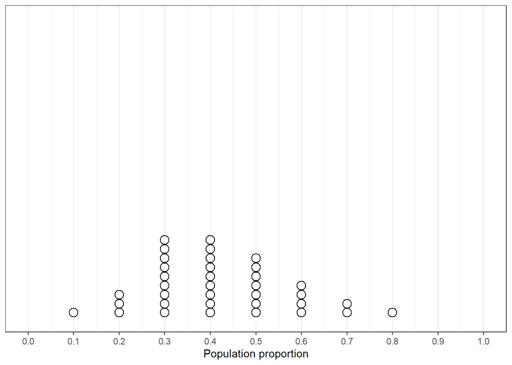

5. What seems to be the consensus of the class? What do we think are the most plausible values of the population proportion? Somewhat plausible? Not plausible?

   *Like a “wisdom of crowds” prior. Most: ~0.3-0.5; somewhat ~0.1-0.2, ~0.6-0.8*
6. The plot just shows our *guesses* for the population proportion. How could we estimate the actual population proportion based on data?

   *Use our class as a sample.*
7. We will treat the 35 students in our class as a sample from the population of current Cal Poly students. But before collecting the data, let’s consider what *might* happen.

   Suppose that the actual population proportion is 0.5. That is, suppose that 50% of current Cal Poly students have read at least one Harry Potter book. How many students in a class of 35 students would you expect to have read at least one Harry Potter book? Would it necessarily be around 17-18 students? How could you use a coin to *simulate* how many students in a class of 35 students *might* have read at least one Harry Potter book?

   *Sampling variability. Can do a coin flipping simulation by hand and collect the results, then use software/applet, e.g. [RossmanChance](http://www.rossmanchance.com/applets/2021/oneprop/OneProp.htm).*
8. Now suppose the actual population proportion is 0.1. How would the previous part change?

   *Now expect around 3-4 but still sampling variability. Can use a ten-sided die to do simulation, then applet.*
9. Using your choice for the most plausible value of the population proportion, simulate how many students in a class of 35 students *might* have read at least one Harry Potter book.

   *Each student should do at least two repetitions. Collect values in a plot like the following.*

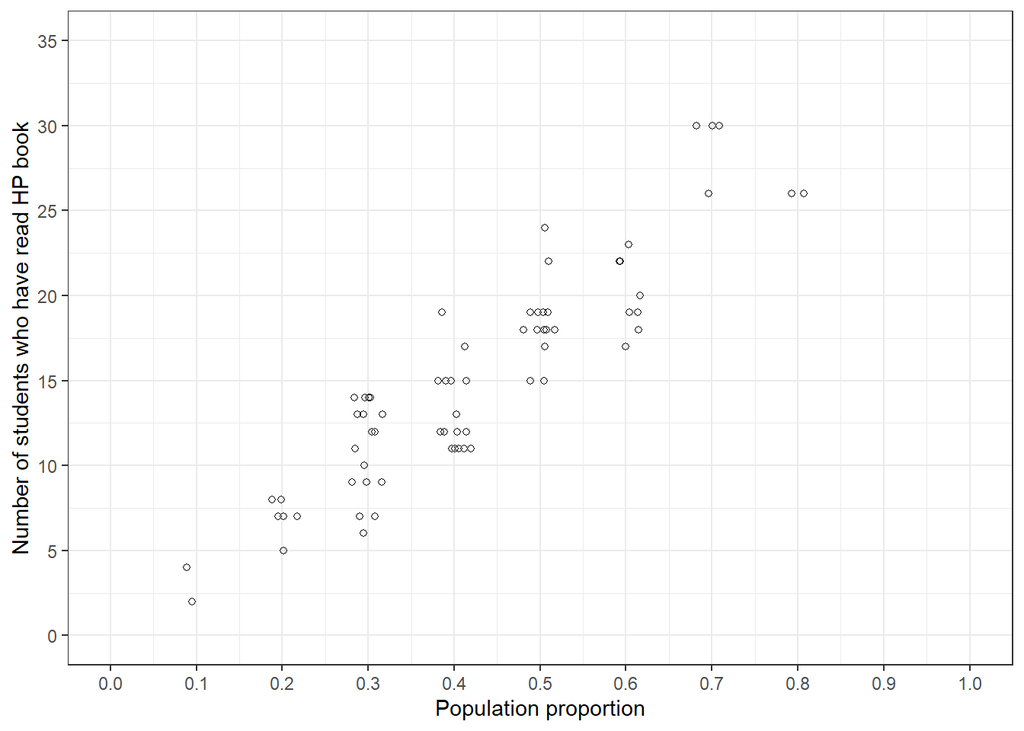

10. Why are there more dots corresponding to a proportion of 0.4 than to a proportion of 0.1?

    *Differences in initial plausibility.*
11. How could we get an even clearer picture of what *might* happen?

    *Conduct more repetitions, using software.*

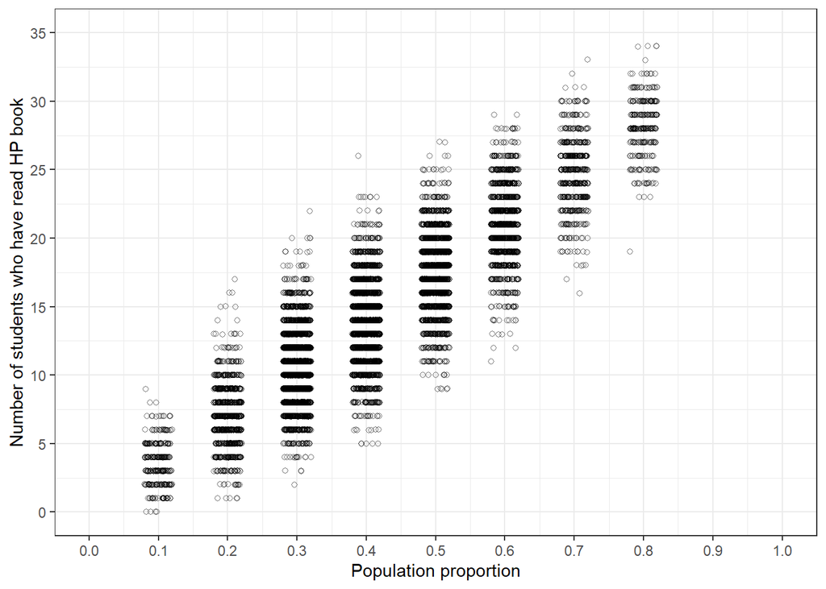

12. The plot above illustrates two sources of uncertainty or variability. What are these two sources?

    *(1) Uncertainty in the value of the population proportion; differences in initial plausibility.* *(2) For a given population proportion, sample-to-sample variability.*
13. So far, everything we’ve considered is what *might* happen in a class of 35 students. Now let’s see what is actually true for our class. (Collect data.) Out of the 35 students in our class, 12 have read at least one Harry Potter book, for a proportion of 12/35 = 0.343. Does this necessarily mean that 34.3% of current Cal Poly students have read at least one Harry Potter book?

    *Parameter versus statistic.*
14. Remember that we started with *guesses* about which values of the population proportion were more plausible than others. How can we reconsider the plausibility of these values in light of our sample data?

    *Previous plots told us what might happen. Let’s focus now on what actually did happen. What values of population proportion seem consistent with observing 12 successes? “Slice out” the dots corresponding to 12 successes.*

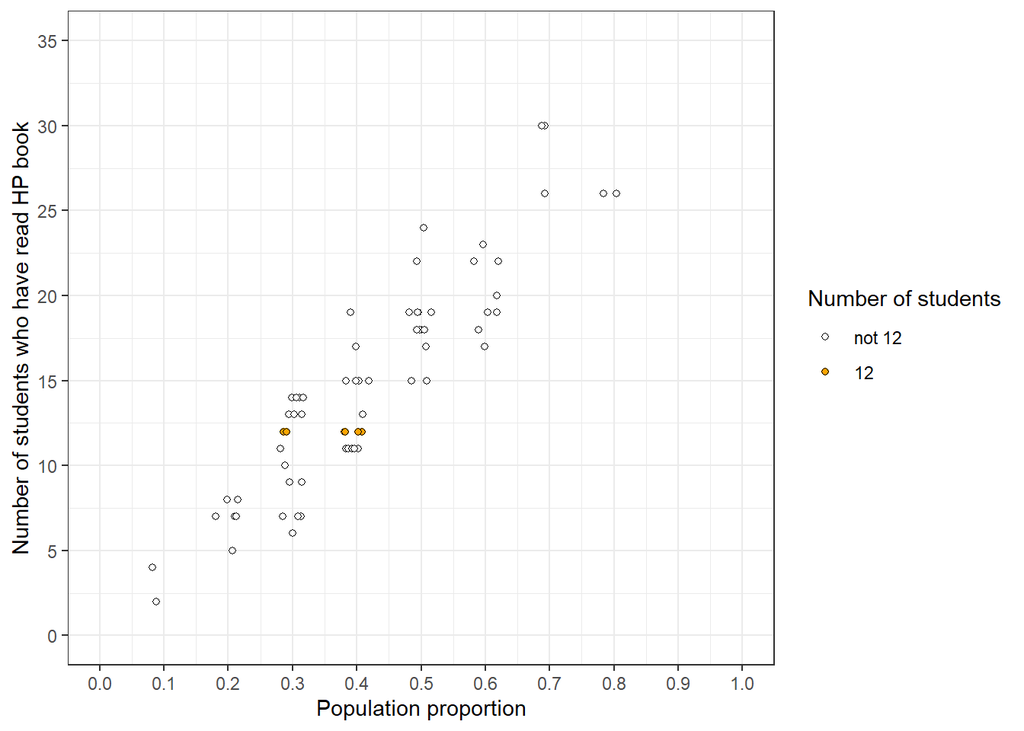

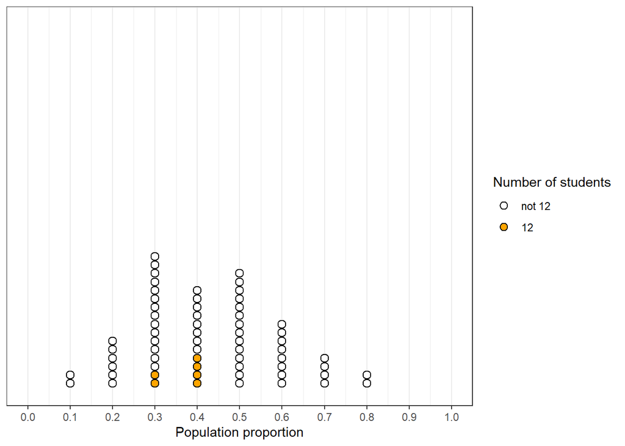

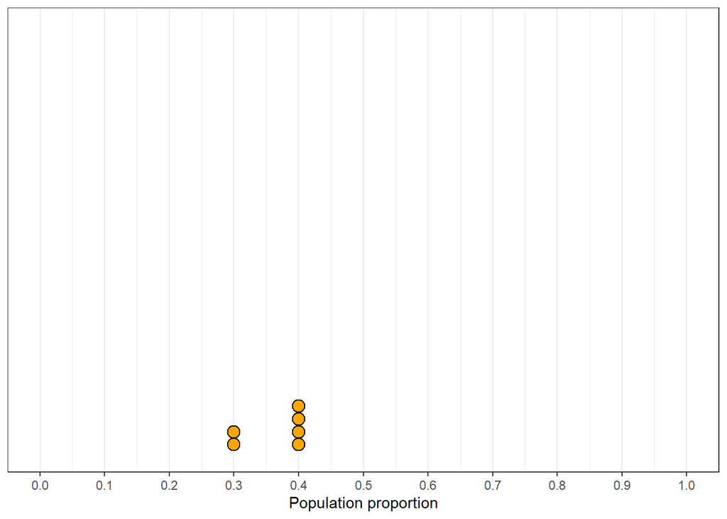

    *Do both for class simulation and software.*

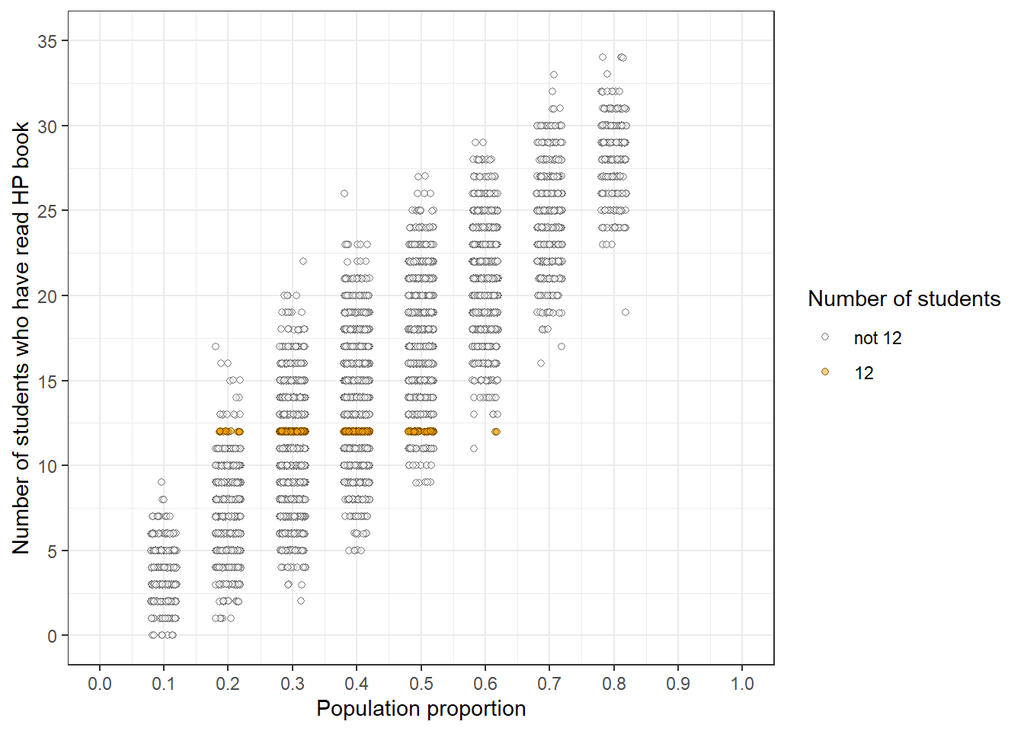

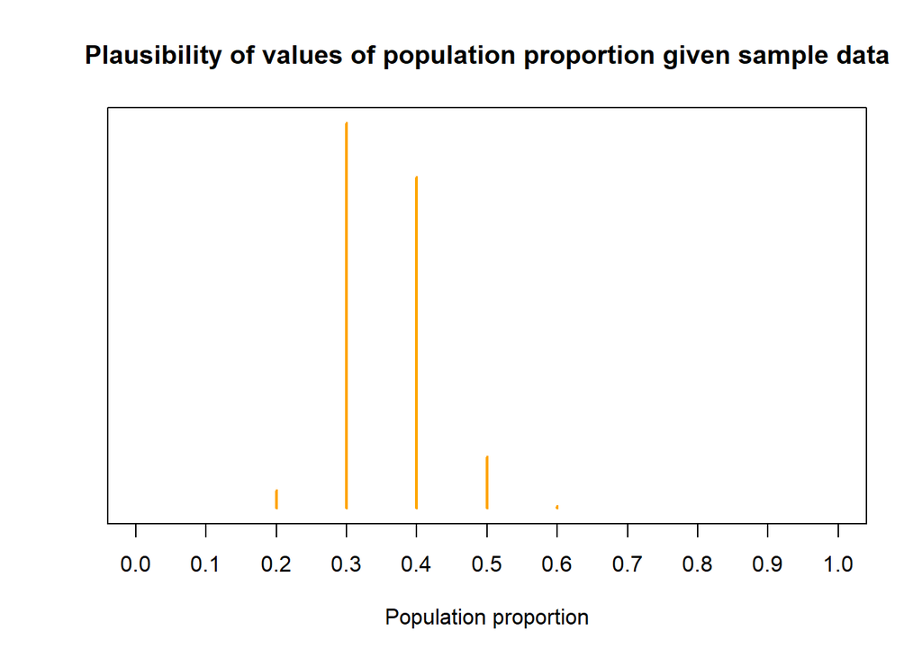

15. After observing a sample of 35 Cal Poly students with a proportion of 12/35 who have read at least one Harry Potter book, what can we say about the plausible values of the *population* proportion? How has our assessment of plausibility changed from before observing the sample data?

    *0.3-0.4 were initially very plausible, and have even greater plausibility now compared to 0.2 and 0.5. Anything outside of 0.2-0.5 seems implausible in light of the sample data.*

## Comments on Activity 1

- The activity hits on all GAISE guidelines, including multivariable thinking
- Might be confusing to collect from students both their guess and their response.
  - Could use previous survey results to motivate prior for Cal Poly, and then use sample data from the class
  - Or could use class prior, but a different sample
- Use an example where you expect a relatively diffuse prior
- Lots of follow up questions/directions
- Compare to population proportion who have watched at least one HP movie (would expect prior to have greater prior mean but smaller prior SD)

# Activity 2: “Second” Day of Inference

- Continuing Activity 1, construct prior via relative plausibility
- Some of the math behind the simulation, but Bayes rule without probability
- Introduces the Bayesian inference framework
  - Parameters are random variables with distributions that quantify degree of uncertainty
  - Posterior is proportional to likelihood times prior
- Discrete to continuous prior

Continuing the Harry Potter (HP) problem.

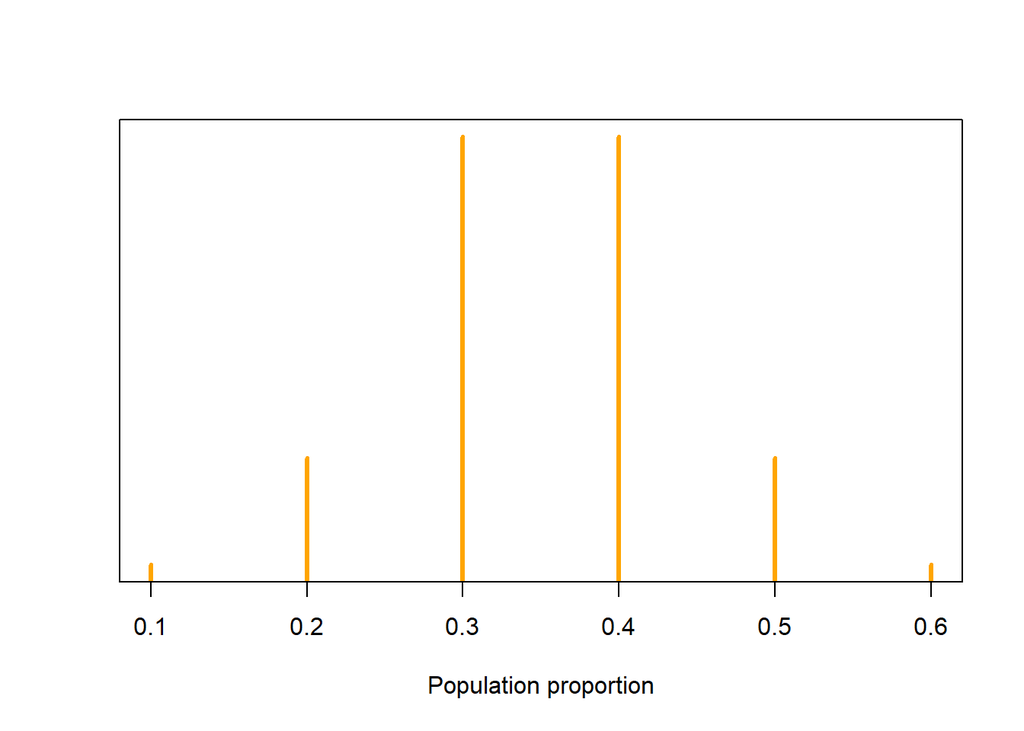

   *Can talk about what we mean by prior distribution. Considering parameter as a random variable, and using distributions to describe degree of uncertainty. For students: parameter is an uncertainty quantity and a prior represents our degree of uncertainty, or our assessment of relative plausibility of possible values of the parameter.*
2. If we simulate many values of the population proportion according to the above distribution, on what proportion of repetitions would we expect to see a value of 0.1? If we conduct 260000 repetitions of the simulation, on how many repetitions would we expect to see a value of 0.1? Repeat for the other plausible values to make a table of what we would expect the simulation results to look like. (For now, we’re ignoring simulation variability.)

   | Population proportion | Prior “Units” | Prior | Number of reps |
   | --- | --- | --- | --- |
   | 0.1 | 1 | 0.038 | 10000 |
   | 0.2 | 3 | 0.115 | 30000 |
   | 0.3 | 9 | 0.346 | 90000 |
   | 0.4 | 9 | 0.346 | 90000 |
   | 0.5 | 3 | 0.115 | 30000 |
   | 0.6 | 1 | 0.038 | 10000 |

3. The above describes our initial assessment of the population proportion prior to observing data. Now suppose we observe a sample of 35 students in which 12 students have read at least one HP book. We want to update our assessment of the population proportion in light of the observed data.

   Suppose that the actual population proportion is 0.5. How could we determine the chances of observing 12 students who have read at least one HP book in a sample of 35 students?

   *Can use simulation/applet. Can mention that there is a formula (Binomial) for this situation.*

   ```
   ## [1] 0.024
   ```

4. Recall the simulation with 260000 repetitions that we started above. Consider the 30000 repetitions in which the population proportion is 0.5. Suppose that for each of these repetitions we simulate the number of students in a class of 35 who have read at least one HP book. On what proportion of these repetitions would we expect to see a sample count of 12? On how many of these 30000 repetitions would we expect to see a sample count of 12?

   ```
   ## [1] 729
   ```

5. Repeat the previous part for the plausible values of the population proportion.

   | Population proportion | Prior “Units” | Prior | Number of reps | Chances of count of 12 | Reps with count of 12 |
   | --- | --- | --- | --- | --- | --- |
   | 0.1 | 1 | 0.038 | 10000 | 0.0001 | 1 |
   | 0.2 | 3 | 0.115 | 30000 | 0.0202 | 605 |
   | 0.3 | 9 | 0.346 | 90000 | 0.1214 | 10923 |
   | 0.4 | 9 | 0.346 | 90000 | 0.1106 | 9950 |
   | 0.5 | 3 | 0.115 | 30000 | 0.0243 | 729 |
   | 0.6 | 1 | 0.038 | 10000 | 0.0013 | 13 |

   *“Chances of 12” column represents the likelihood function, the probability of observing the given data as a function of the parameters. The likelihood function is the probability/density of a single event computed under different scenarios. The likelihood function is not a probability distribution, so the likelihood column will not sum to anything in particular.*
6. Consider just the 22221 repetitions that resulted in a simulated sample count of 12. What proportion of these repetitions correspond to a population proportion of 0.4? Of 0.5? Sketch this *posterior distribution*.

   | Population proportion | Prior “Units” | Prior | Number of reps | Chances of count of 12 | Reps with count of 12 | Posterior |
   | --- | --- | --- | --- | --- | --- | --- |
   | 0.1 | 1 | 0.038 | 10000 | 0.0001 | 1 | 0.0000 |
   | 0.2 | 3 | 0.115 | 30000 | 0.0202 | 605 | 0.0272 |
   | 0.3 | 9 | 0.346 | 90000 | 0.1214 | 10923 | 0.4916 |
   | 0.4 | 9 | 0.346 | 90000 | 0.1106 | 9950 | 0.4478 |
   | 0.5 | 3 | 0.115 | 30000 | 0.0243 | 729 | 0.0328 |
   | 0.6 | 1 | 0.038 | 10000 | 0.0013 | 13 | 0.0006 |

7. After observing a sample of 35 Cal Poly students with a proportion of 12/35 who have read at least one Harry Potter book, what can we say about the plausible values of the *population* proportion? How has our assessment of plausibility changed from before observing the sample data?

   *Compare posterior to prior, similar to Activity 1.*
8. Prior to observing data, how many times more plausible is 0.4 than 0.5 for the population proportion? How many times more likely is a count of 12 in a sample of size 35 when the population proportion is 0.4 than when it is 0.5? After observing data, how many times more plausible is 0.4 than 0.5 for the population proportion? How are these three values related?

   $$\begin{align*}
   \frac{0.4478}{0.0328} & = \left(\frac{9/26}{3/26}\right) \times \left(\frac{0.1106}{0.0242}\right)\\
   13.66 & = 3 \times 4.55\\
   & \\
   \text{posterior} & \propto \text{prior} \times \text{likelihood}
   \end{align*}$$

   *Posterior is proportional to product of prior and likelihood.*
9. What is the problem with considering only the values 0.1, 0.2, …, 0.6 as plausible? How could we resolve this issue?

   *Expand the grid and assign relative plausibility to the in between values. Connect the dots to move to continuous prior.*

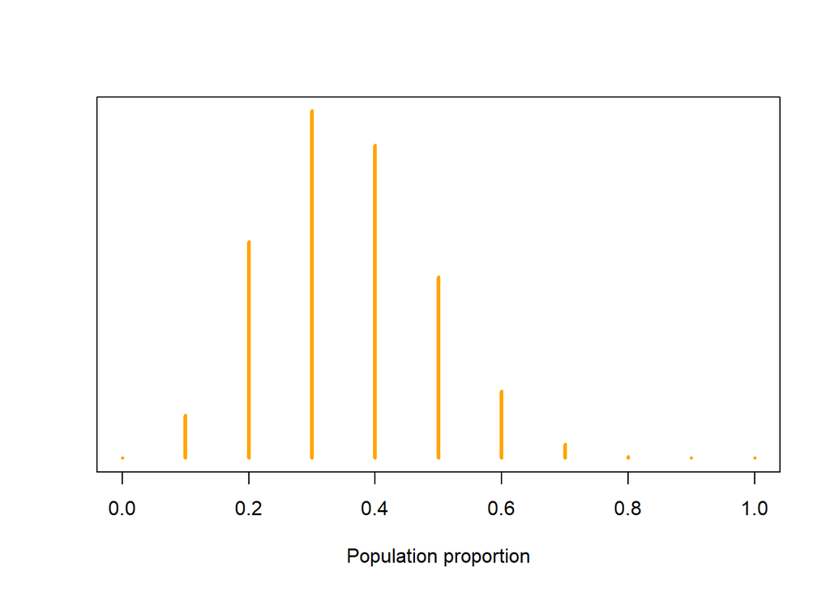

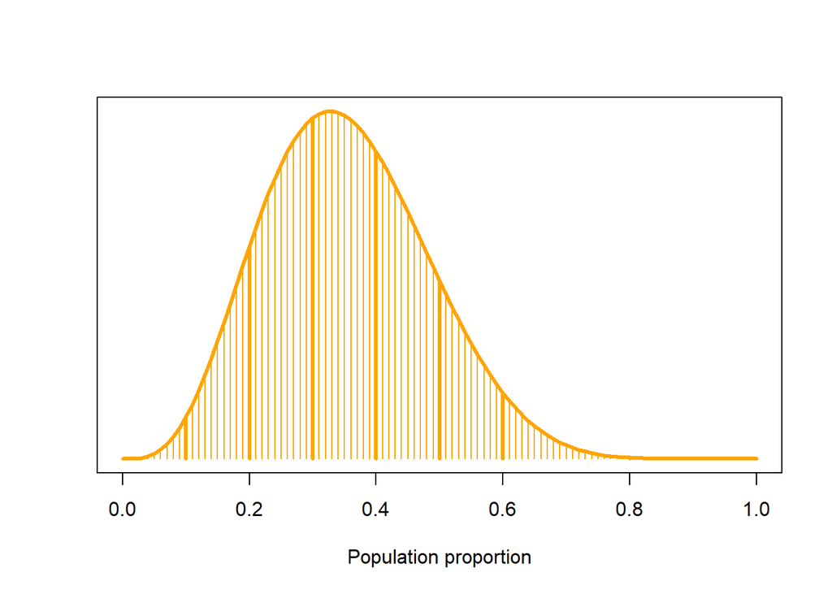

10. Suppose we have a prior distribution that assigns initial relative plausibility to a fine grid of possible values of the population proportion, e.g., 0, 0.0001, 0.0002, 0.0003, …, 0.9999, 1. If we observe a count of 12 in a sample of size 35, how could we update the relative plausibility to find a posterior distribution for the population proportion?

    *For each potential value of the parameter, find probability of observing a count of 12 in a sample of size 35 (likelihood). Find product of prior and likelihood to obtain posterior relative plausibility. Rescale to sum to 1.*

    *It’s helpful to plot prior and posterior on the same plot, and the likelihood can be added too. Prior and posterior are on probability/density scale, but likelihood is not, so rescale the likelihood function so that it is on a common scale.*

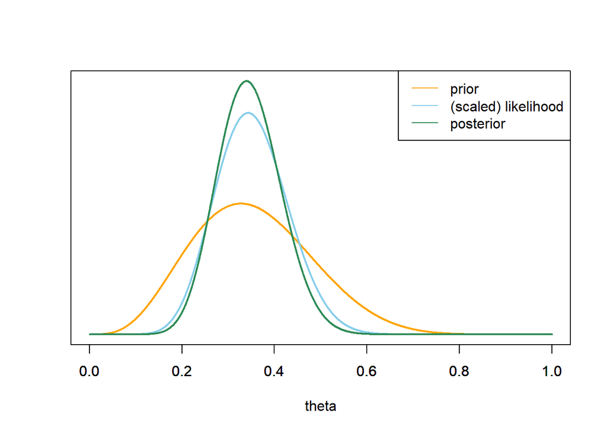

11. How could we use the posterior distribution to fill in the blank in the following: “There is a 90% chance that fewer than [blank] percent of current Cal Poly students have read at least one HP book.”

    *Given the posterior distribution, simulate values of the parameter (according to the posterior) and use the simulated values to approximate posterior probabilities, credible intervals, mean, SD, etc. Ask a series of questions to summarize and report conclusions based on the posterior distribution.*

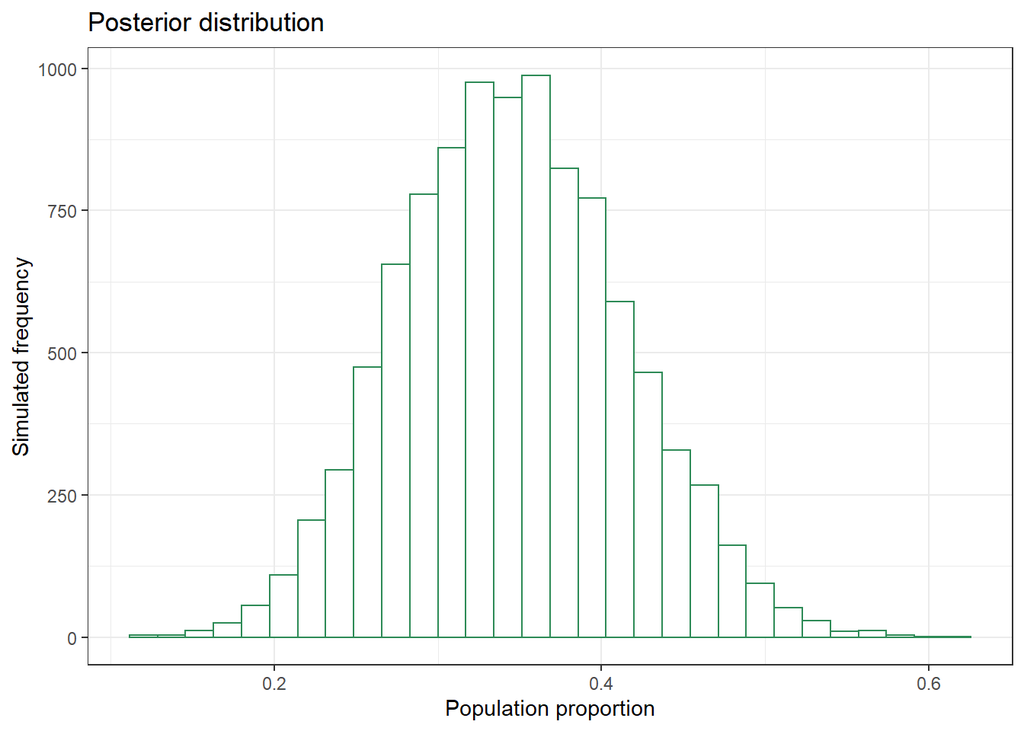

    ```r
    post_sim = data.frame(theta_sim =
                        sample(theta, 10000, replace = TRUE, prob = posterior))

    ggplot(post_sim, aes(theta_sim)) +
      geom_histogram(fill = "white", color = "seagreen") +
      labs(x = "Population proportion",
       y = "Simulated frequency",
       title = "Posterior distribution") +
      theme_bw()
    ```

    ```r
    quantile(post_sim$theta_sim, 0.9)
    ```

    ```
    ##  90%
    ## 0.44
    ```

    ```r
    mean(post_sim$theta_sim < 0.5)
    ```

    ```
    ## [1] 0.99
    ```

## Comments on Activity 2

- Use counts instead of proportions.
- Don’t have to avoid probability entirely, but you can avoid a lot of it if you want.
- Regarding prior/posterior, “plausible” maybe not the best word; “likely” instead?
- Lots of “proportions” and lots of stages to the simulations.
  - Use frequent reminders of what each proportion is, and what is happening at each stage of the simulations.
- Choose better values for the small discrete prior probabilities to match with the eventual continuous prior (e.g., proportional to dbeta(theta, a, b).)
- In Bayesian inference, the entire posterior distribution is the inference.
  - Try not to just summarize the posterior in a single interval or posterior probability.
  - Instead report, say, a collection of intervals (50%, 80%, 95%, etc)
- Be sure to spend ample time on the data and conclusions, not just the analysis.

# Activity 3: “End” of Course

- After frequentist, why Bayesian?

You have two friends, Mabel and Dipper, who each makes a claim.

Mabel says: “I’ve been learning to use the Force! (Like in Star Wars.) If you roll a fair four-sided die, I can [use the Force to make it land on a 1](https://www.starwars.com/video/a-game-of-chance)! I’m still learning, so I can’t do it every time, but it definitely works sometimes!”

Dipper, a baseball player, says: “Ever since baseball season ended, I’ve been practicing really hard to improve my hitting. Last season I got hits in 25% of my at bats, but I’ve definitely improved since then.”

Before reading further, stop to consider: whose claim - Mabel’s or Dipper’s - is initially more convincing? Or are you equally convinced? Why? (To put it another way, whose claim are you initially more skeptical of? Or are you equally skeptical?) (To put it one more way, whose claim would require more data to convince you?)

You decide to collect some data from Mabel and Dipper to investigate their claims.

To investigate Mabel’s claim you roll a fair four-sided die and have Mabel use the Force to make the die land on 1. After 100 rolls, the die has landed on 1 33 times. (You can assume the die is fair, the rolls are independent, and there is no funny business in data collection (other than Mabel’s use of the Force).)

To investigate Dipper’s claim you have him take a series of at bats. After 100 at bats, Dipper has gotten 33 hits. (You can assume Dipper’s probability of getting a hit on any single at bat is the same for each at bat, the at bats are independent, you can ignore baseball context like walks/etc., and there is no funny business in data collection.)

1. Use the results of the 100 trials to conduct a null hypothesis test for Mabel and compute the p-value.
2. Repeat the previous part for Dipper.
3. Based on the results of the hypothesis tests, whose claim - Mabel’s or Dipper’s - is more convincing? Or are you equally convinced? Why?
4. Now use the results of the 100 trials to perform a Bayesian analysis for Mabel. Be sure to specify your prior distribution and explain why you chose that prior. Find and interpret the posterior distribution and assess the plausibility of Mabel’s claim.
5. Repeat the previous part for Dipper.
6. Based on the results of the Bayesian analyses, whose claim - Mabel’s or Dipper’s - is more convincing? Or are you equally convinced? Why?
7. In this situation, which analysis do you prefer: the frequentist analysis or the Bayesian analysis? Why? There is no right or wrong answer to this question, but you should state a clear preference and explain why it is more appealing to you.

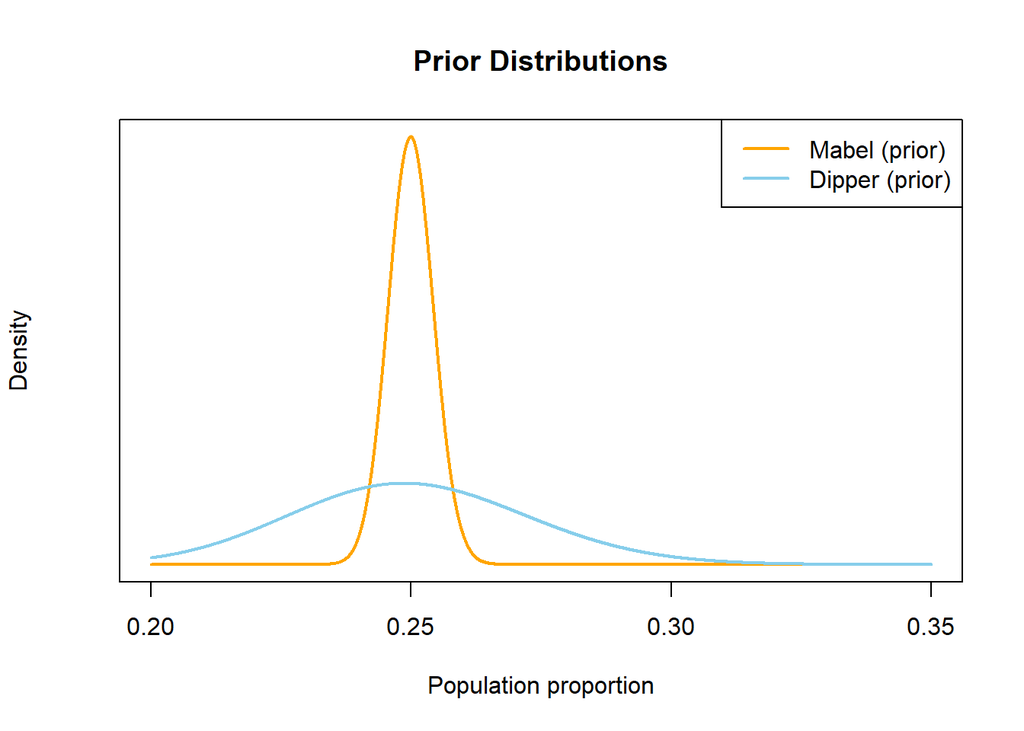

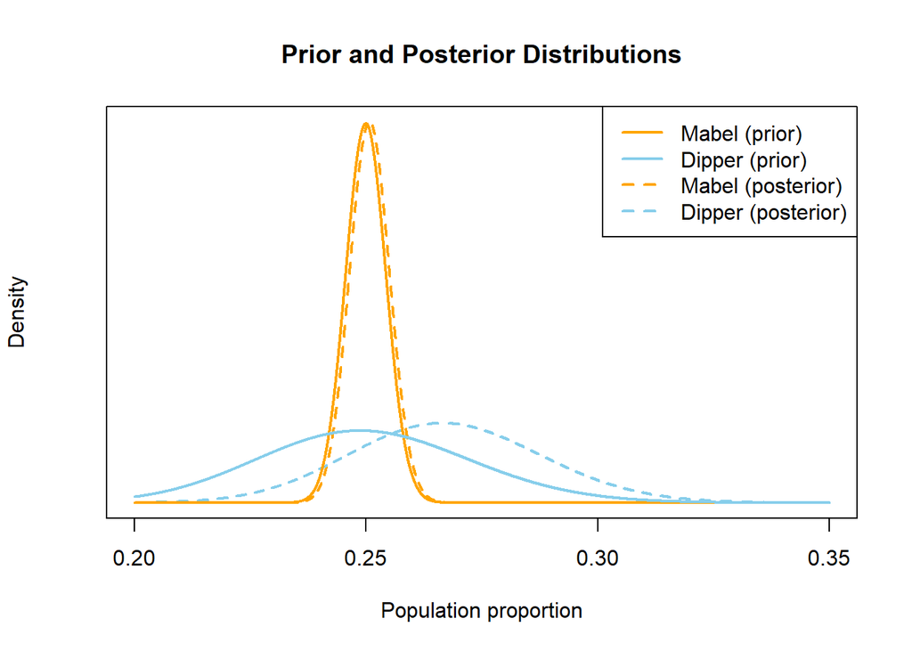

## Comments on Activity 3

- Where to start depends on what Bayesian ideas you have already introduced.
- Can discuss what would be a meaningful difference, rather than just $p>0.25$.
- Compare posterior probabilities or intervals between Mabel and Dipper.
- Bayesian versus frequentist is not “right versus wrong” but rather different sets of tools.